# Visuals for Quantitative Data

Muhammad Hilmi Abdul Majid

## Introduction

In the previous topic, we have seen some visuals we can use to represent categorical data. We will continue with exploring various visual and graph options that can be used to describe or show the distribution of data in this topic. However, we will look at quantitative data, where data is written in numbers. For example, the data may refer to a person’s height, weight, age, salary, and so on.

We load the `ggplot2` and `dplyr` packages as usual first. Additionally, we will use the `Marriage` data again from the the `mosaicData` package.

```r
library(ggplot2)
library(dplyr)
library(mosaicData)
```

## Histogram

The most commonly used visual used to show the distribution of quantitative data is the histogram. Histogram is similar to a bar chart, where rectangles or bars are drawn and the height of the bar represents a group’s frequency or relative frequency. However, in histogram, groups are formed in bins by combining observations into intervals.

To draw a histogram in ggplot2, we can use `geom_histogram()` function.

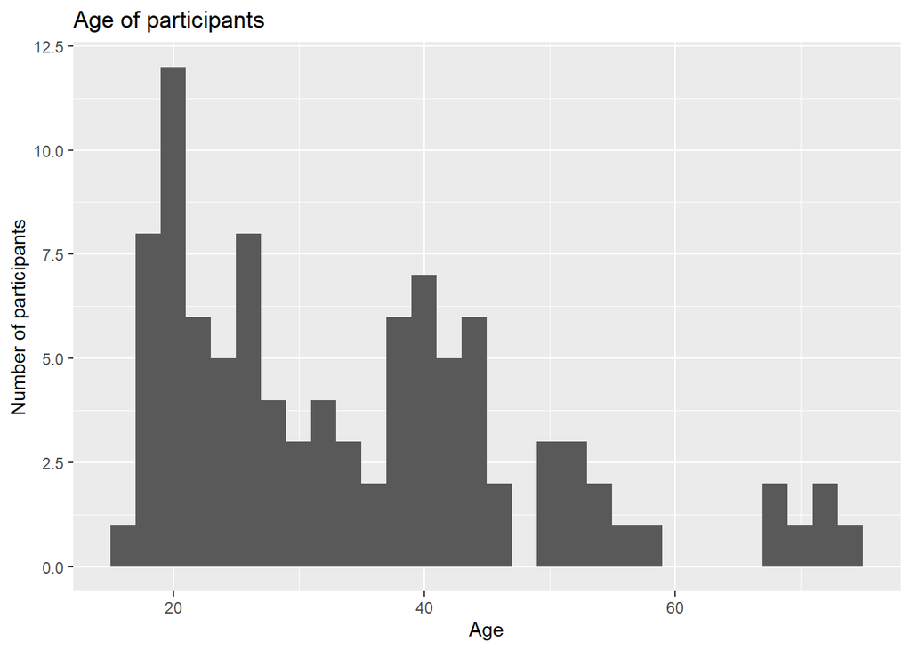

```r
ggplot(data = Marriage, mapping = aes(x=age)) +
  geom_histogram() +
  labs(title="Age of participants", y="Number of participants", x="Age")
```

As we can see from the histogram, most of the marriage participants are in their early 20’s. But we an also see another group of participants in their 40’s. The minimum and maximum age is around 15 and 75 years, respectively.

### Specifying bins

If we want to specify the width of the group intervals, we can either use `binwidth` or `bins` argument in the `geom_histogram()`. The `binwidth` is used to specify the width of the intervals, and `bins` is used to specify how many bins (or groups) we wishes to have.

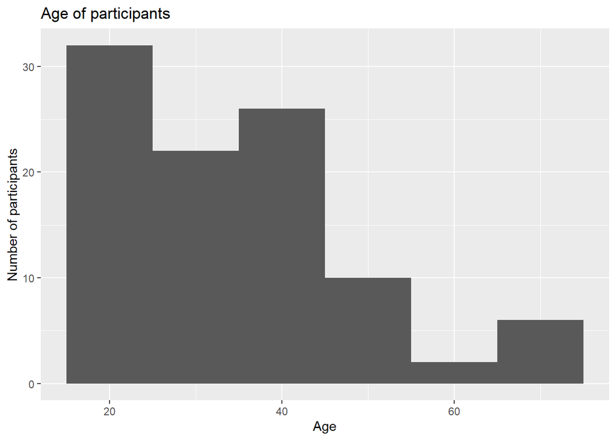

```r
ggplot(data = Marriage, mapping = aes(x=age)) +
  geom_histogram(binwidth = 10) +
  labs(title="Age of participants", y="Number of participants", x="Age")
```

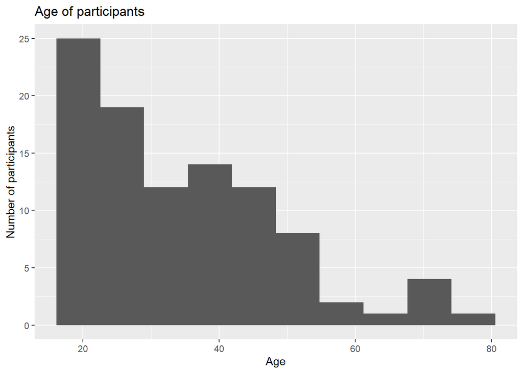

```r
ggplot(data = Marriage, mapping = aes(x=age)) +
  geom_histogram(bins = 10) +
  labs(title="Age of participants", y="Number of participants", x="Age")
```

Alternatively, we can use `breaks` argument in `geom_histogram()` to specify the bin boundaries.

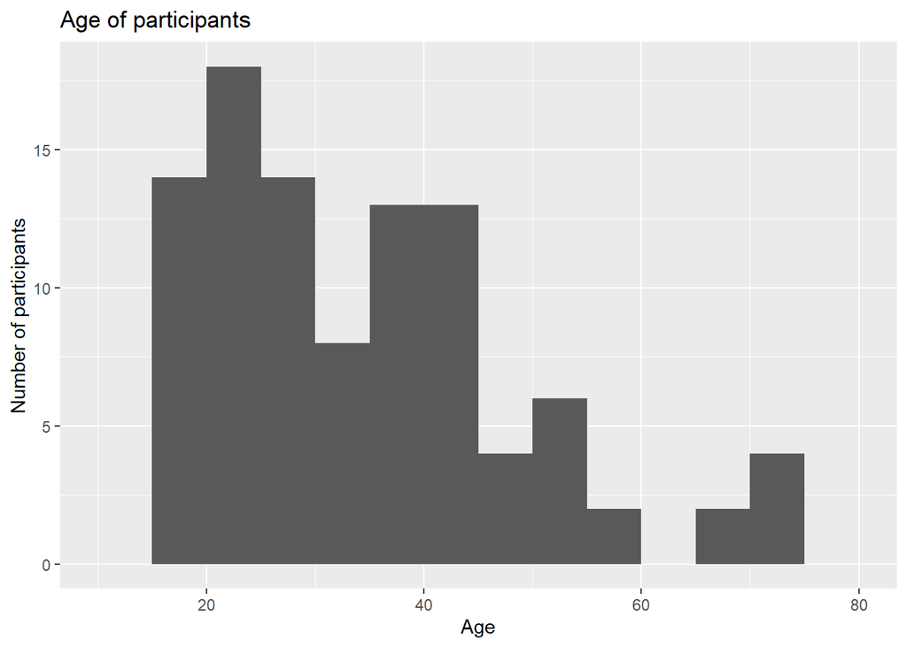

```r
ggplot(data = Marriage, mapping = aes(x=age)) +
  geom_histogram(breaks = c(10,15,20,25,30,35,40,45,50,55,60,65,70,75,80)) +
  labs(title="Age of participants", y="Number of participants", x="Age")
```

### Relative frequency as the y-axis

We can also use relative frequencies or percentages for the y-axis. To do that, we can use `after_stat()` function in the `aes()` to calculate the relative frequency. Then, we use `scale_y_continuous()` and use the `label_percent()` from the `scales` package to make the y-axis in percentages.

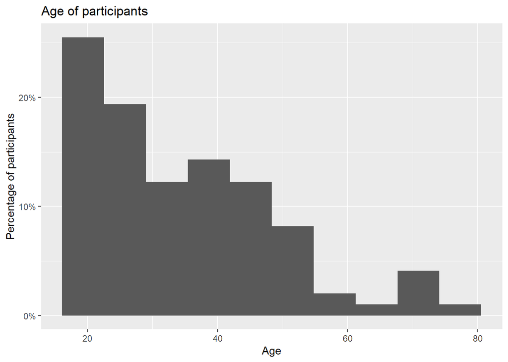

```r
ggplot(data = Marriage,
       mapping = aes(x=age,
                     y=after_stat(count/sum(count)))) +
  geom_histogram(bins = 10) +
  labs(title="Age of participants", y="Percentage of participants", x="Age") +
  scale_y_continuous(labels = scales::label_percent())
```

### Modifying colors and line

The colors in the the histogram can be modified using the `fill` and `color` arguments in the `geom_histogram()`. The `fill` argument specifies the color of the inside of the rectangles, and `color` specifies the line or border of the rectangles. The `size` argument can also be used to modify the width of the borders.

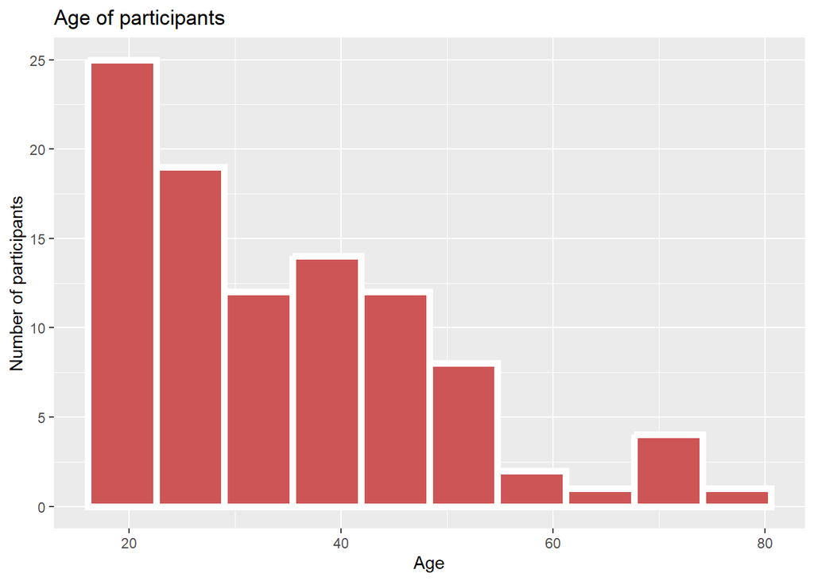

```r
ggplot(data = Marriage, mapping = aes(x=age)) +
  geom_histogram(bins = 10,
                 fill = "indianred3",
                 color = "white",
                 size = 2) +
  labs(title="Age of participants", y="Number of participants", x="Age")
```

## Kernel Density Plot

The kernel density plot (or simply density plot) is another tool that can be used to display the distribution of quantitative data. It is very similar to the histogram. In kernel density plot we try to visualize the *probability distribution* of the data by drawing a curve or line that represents the distribution. To form the curve, we first form several curve called kernel for every data we have. The kernel used in typically the Gaussian or the normal distribution centered around observed data value with a chosen bandwidth or variance. Then we add all the curves from all the observed data to get one single curve to represent all data.

In ggplot, we use `geom_density()` to draw the kernel density plot.

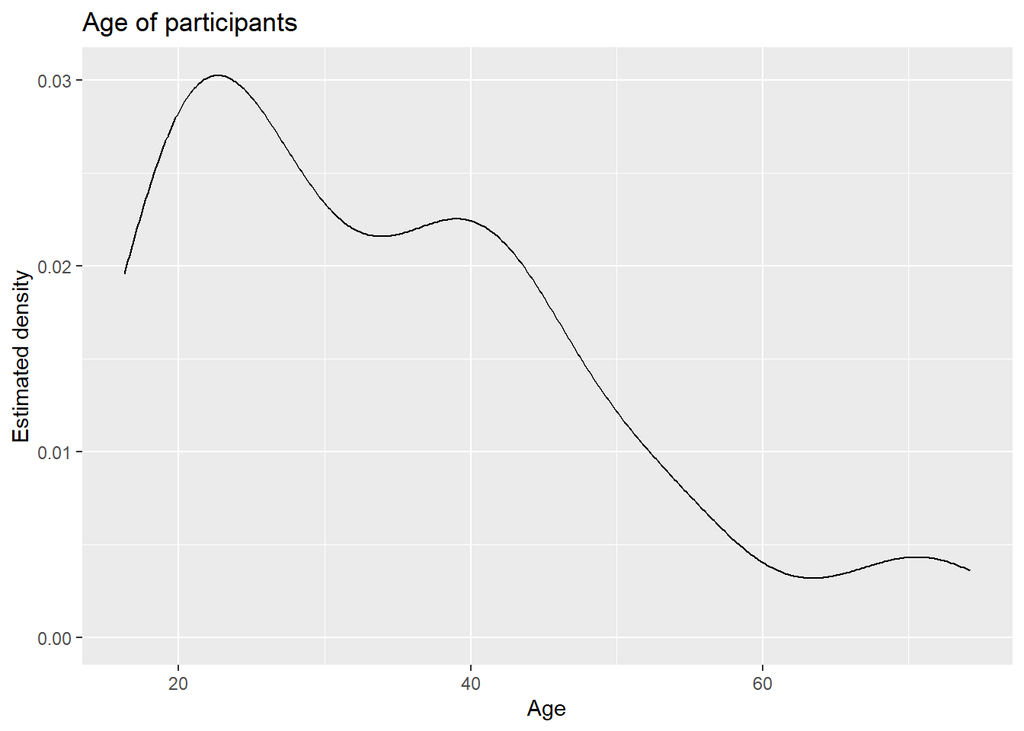

```r
ggplot(data = Marriage, mapping = aes(x=age)) +
  geom_density() +
  labs(title="Age of participants", y="Estimated density", x="Age")
```

We can see that the distribution is bimodal with two modes (or peaks). One is at around the age of 23, and another is at the age of 40.

### Kernel bandwidth

Since the kernel density uses the kernel curves, the difference in the kernel bandwidth (also called the smoothing parameter) used matters. By default, R will choose a rule-of-thumb value for the bandwidth automatically. However, we can specify the bandwidth ourselves using the `bw` argument in `geom_density()`.

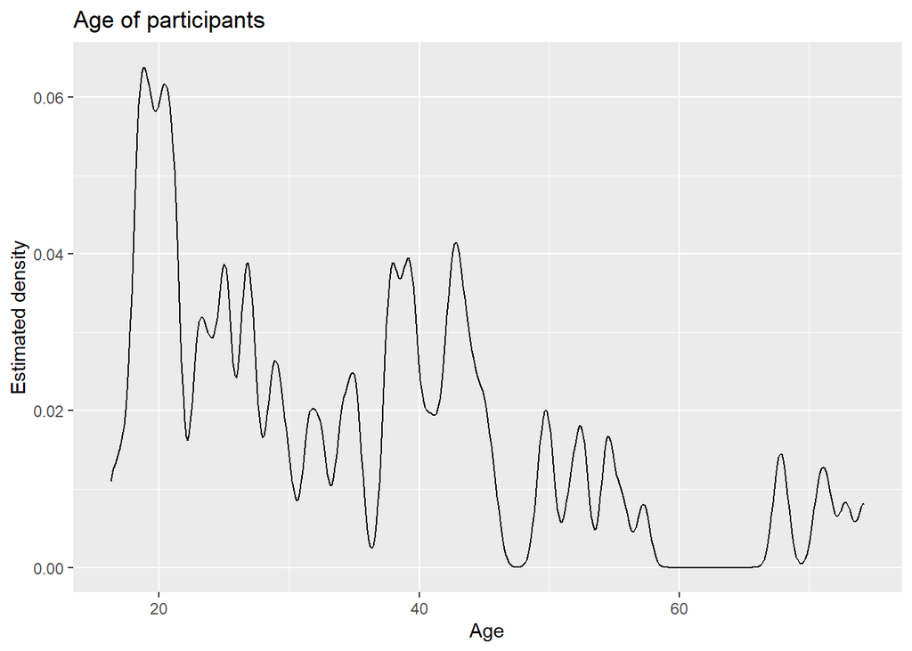

```r
ggplot(data = Marriage, mapping = aes(x=age)) +
  geom_density(bw=0.5) +
  labs(title="Age of participants", y="Estimated density", x="Age")
```

In the example above, we use an extremely small bandwidth for the kernel. Thus, the individual kernels around each observed data are very thin with small variance. Thus, when the individual kernels are added together, we get a very wiggly line.

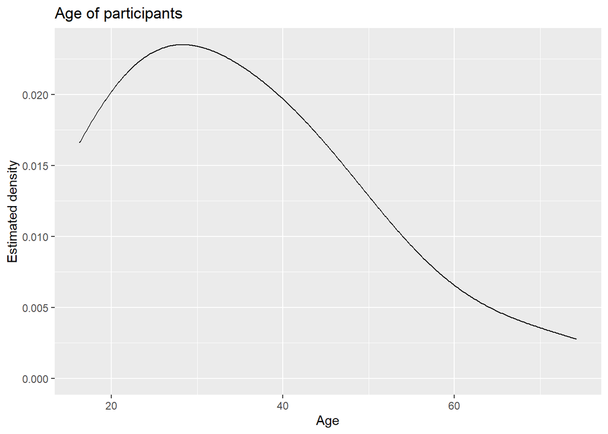

```r
ggplot(data = Marriage, mapping = aes(x=age)) +
  geom_density(bw=10) +
  labs(title="Age of participants", y="Estimated density", x="Age")
```

On the other hand, if we use an extremely high bandwidth as the example above, we get a very smooth and less wiggly curve. However, doing this is not recommended as we lose details and information that we might observed if we use a smaller bandwidth.

### Modifying colors and line

The colors in the kernel density plot can be specified using `fill` and `color` argument in the `geom_density()`. The `fill` specifies the color under the curve, while `color` specifies the color of the line or curve. Additionally, the `size` argument can be used if we want to modify the width of the line.

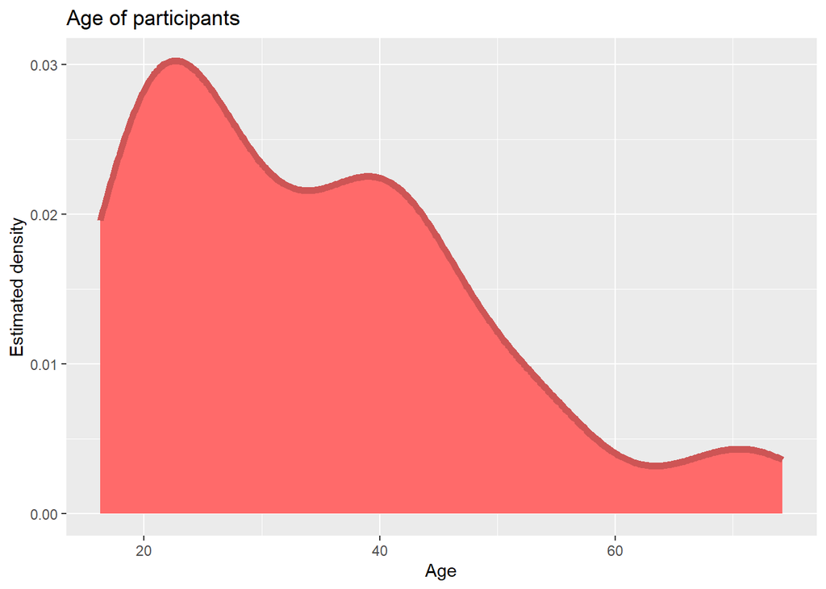

```r
ggplot(data = Marriage, mapping = aes(x=age)) +
  geom_density(fill = "indianred1",
               color = "indianred3",
               size = 2) +
  labs(title="Age of participants", y="Estimated density", x="Age")
```

## Frequency Polygon

Frequency polygon is similar to histogram. Quantitative data are first grouped into bins and when plotted, the y-axis represents the frequency or relative frequency for each bin. However, unlike histogram, frequency polygon uses lines that connect the middle value of a bin to another.

To draw a frequency polygon using ggplot2, we use the `geom_freqpoly()` function.

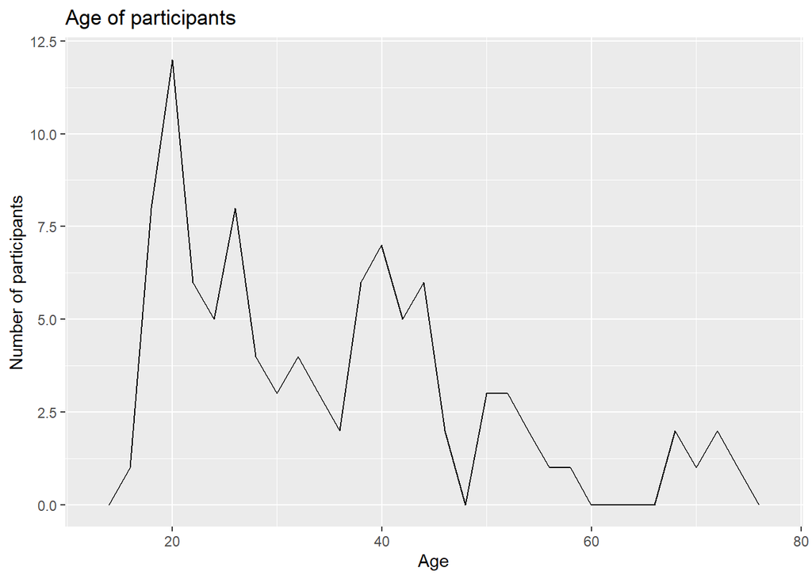

```r
ggplot(data = Marriage, mapping = aes(x=age)) +
  geom_freqpoly() +
  labs(title="Age of participants", y="Number of participants", x="Age")
```

The arguments required for `geom_freqpoly()` is similar to `geom_histogram()`. For example, we can modify the bins using `binwidth`, `bins`, or `breaks`. Line width and color can also be modified using `size` and `color`.

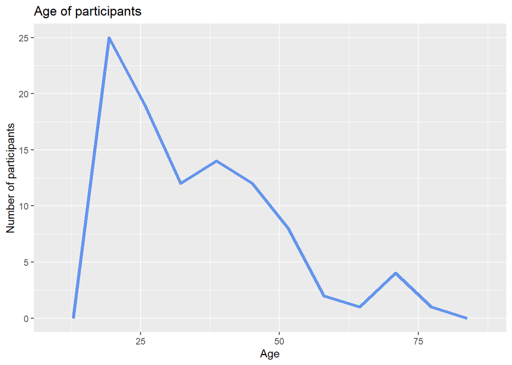

```r
ggplot(data = Marriage, mapping = aes(x=age)) +
  geom_freqpoly(bins = 10,
                color = "cornflowerblue",
                size = 1.5) +
  labs(title="Age of participants", y="Number of participants", x="Age")
```

However, the `fill` argument does not affect `geom_freqpoly`. If the filled frequency polygon is desired, we may have to use `geom_area()` instead.

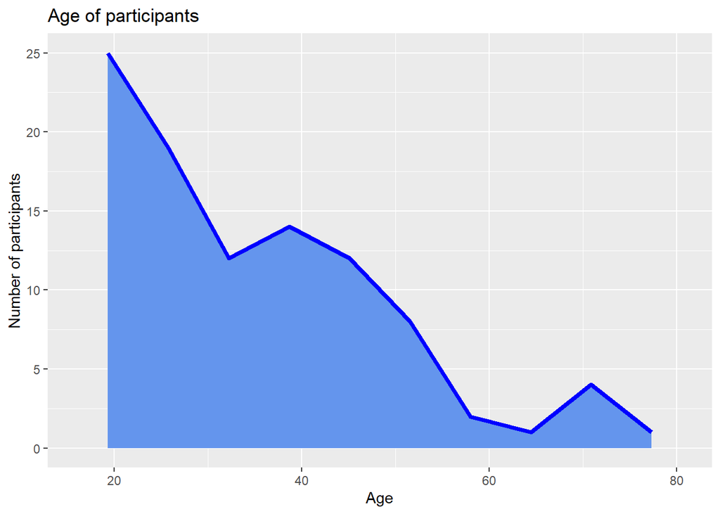

```r
ggplot(data = Marriage, mapping = aes(x=age)) +
  geom_area(mapping = aes(y=..count..),
            bins = 10,
            stat = "bin",
            color = "blue",
            fill = "cornflowerblue",
            size = 1.5) +
  labs(title="Age of participants", y="Number of participants", x="Age")
```

Note that `geom_area()` starts the line from the first middle value of the lower bin, whereas `geom_freqpoly()` starts the line from 0. If we want to starts with 0 using `geom_area()`, we can use `breaks` argument to add a group or interval with no observations.

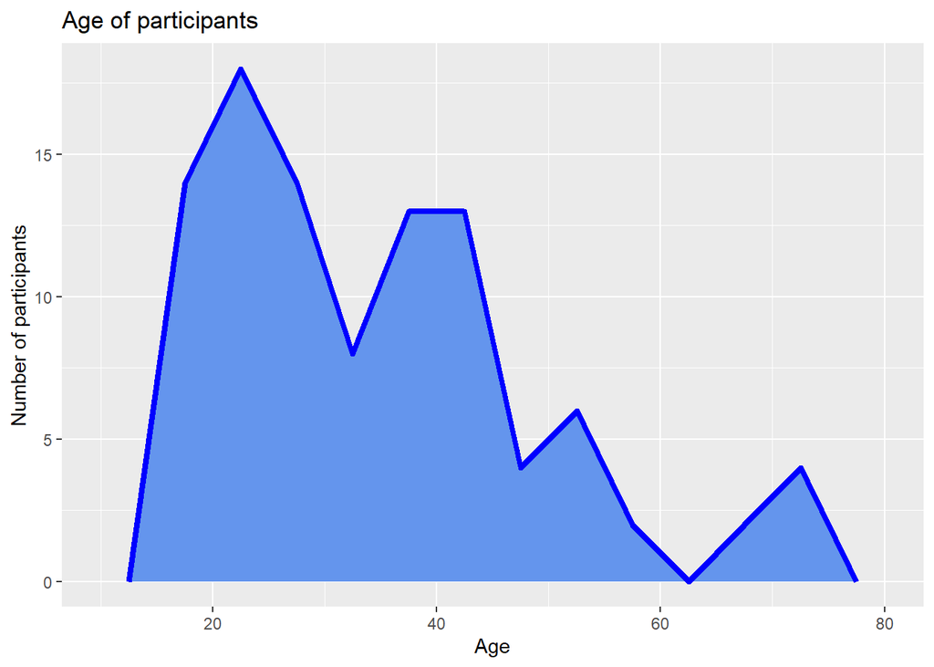

```r
ggplot(data = Marriage, mapping = aes(x=age)) +
  geom_area(mapping = aes(y=..count..),
            breaks=c(10,15,20,25,30,35,40,45,50,55,60,65,70,75,80),
            stat = "bin",
            color = "blue",
            fill = "cornflowerblue",
            size = 1.5) +
  labs(title="Age of participants", y="Number of participants", x="Age")
```

## Boxplot

Boxplot or box-and-whisker plot is a plot that shows the summary of the quantitative data. It first identify the minimum, maximum, and the three quartiles of the data. The three quartiles divide the data into four parts, each containing 25% of the data. For example, there are 25% of data between the minimum value and the first quartile, another 25% of data between the first quartile and the second quartile, and so on.

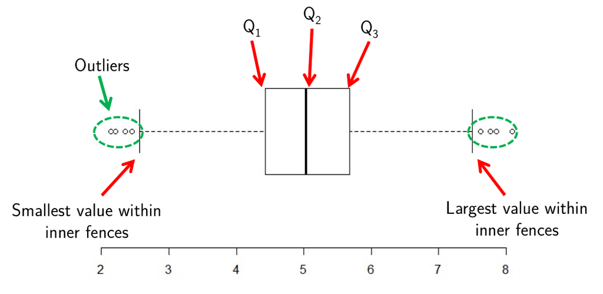

An example of boxplot

Boxplot can also be used to identify outliers in the data, by using *inner fences* that are calcucated using the three quartiles. Any values outside of the inner fences can be considered as outliers.

The boxplot can drawn using `geom_boxplot()` in ggplot2. If we only draw one boxplot (as compared to multiple boxplots that will be covered in the following topic), we might want to modify the theme by removing the unused axis ticks.

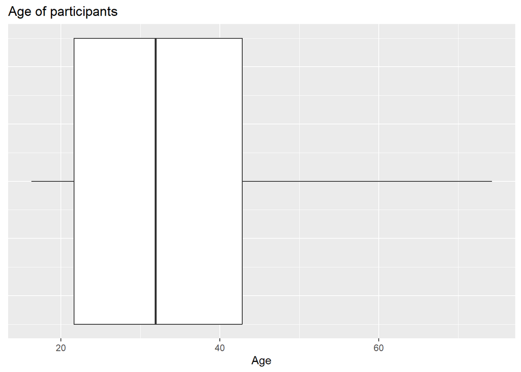

```r
ggplot(data = Marriage, mapping = aes(x=age)) +
  geom_boxplot(width=0.5) +
  labs(title="Age of participants", x="Age") +
  theme(axis.text.y = element_blank(),
        axis.ticks.y = element_blank())
```

From the above plot, we can see that 50% of participants are less than 32-years old. We also see that the data is skewed to the right (or positively skewed) as the boxplot has longer whisker on the right. There is also no outlier in the data.

We can modify the orientation of the boxplot by changing the `aes()` mapping in `ggplot` by using the `y` argument instead of `x`.

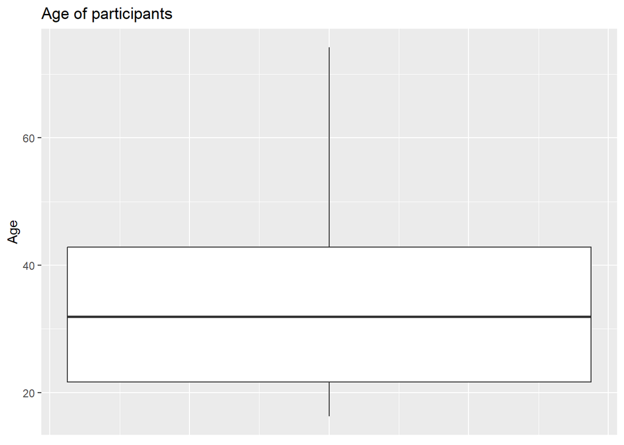

```r
ggplot(data = Marriage, mapping = aes(y=age)) +
  geom_boxplot() +
  labs(title="Age of participants", y="Age") +
  theme(axis.text.x = element_blank(),
        axis.ticks.x = element_blank())
```

Additionally, the colors can be modified using `fill` and `color` arguments in the `geom_boxplot()`.

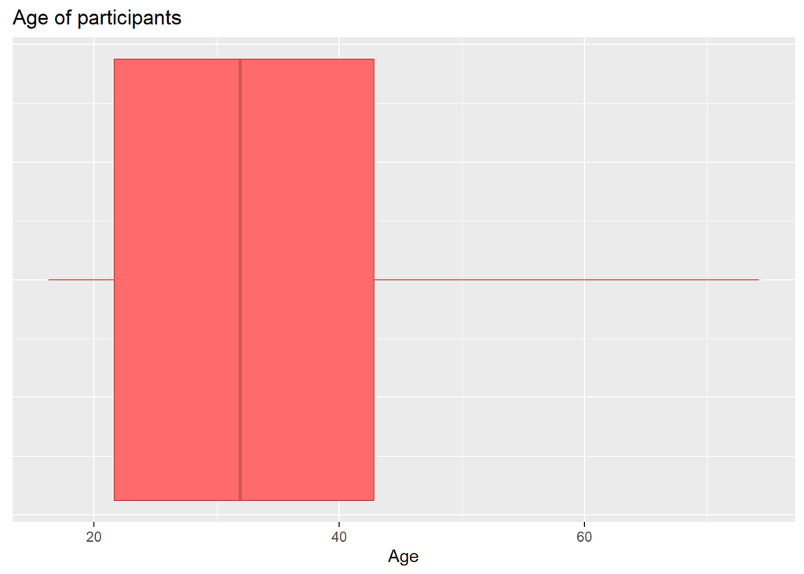

```r
ggplot(data = Marriage, mapping = aes(x=age)) +
  geom_boxplot(fill = "indianred1",
               color = "indianred3") +
  labs(title="Age of participants", x="Age") +
  theme(axis.text.y = element_blank(),
        axis.ticks.y = element_blank())
```

While the boxplot is useful to show summarization of the data, it does not show the data itself. To show the data, we can add points or jitters in the boxplot that shows the position of each individual observed data. We can either use `geom_point()` to add points on the line.

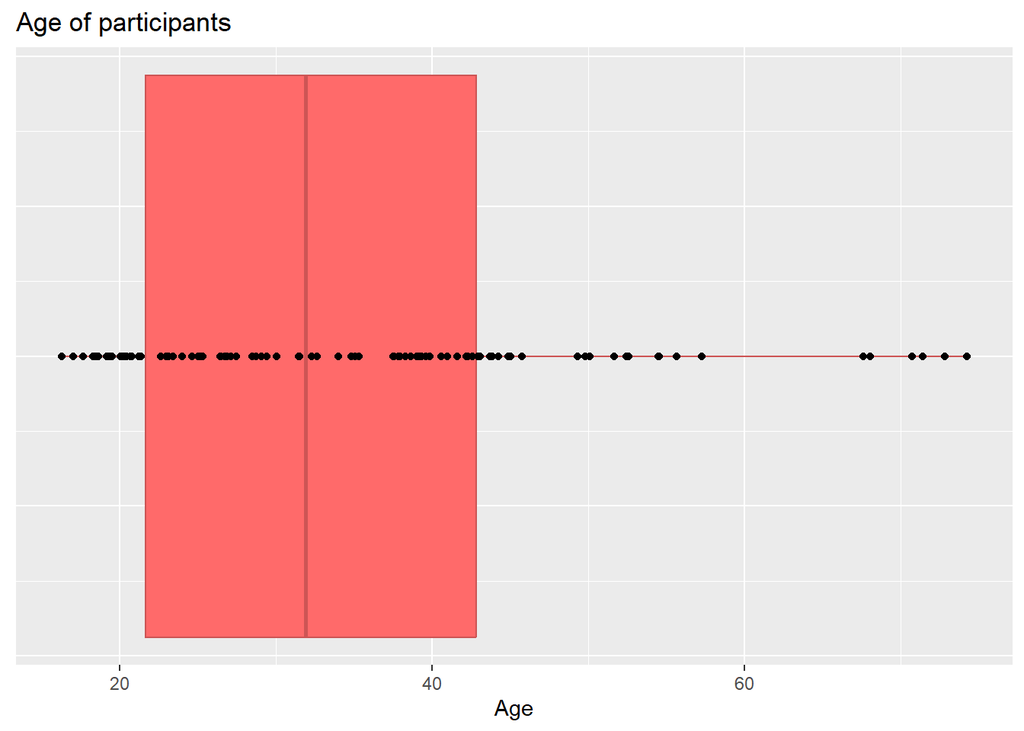

```r
ggplot(data = Marriage, mapping = aes(x=age)) +
  geom_boxplot(fill = "indianred1",
               color = "indianred3") +
  geom_point(aes(y=0)) +
  labs(title="Age of participants", x="Age", y=NULL) +
  theme(axis.text.y = element_blank(),
        axis.ticks.y = element_blank())
```

Or use `geom_jitter()` to add jitters.

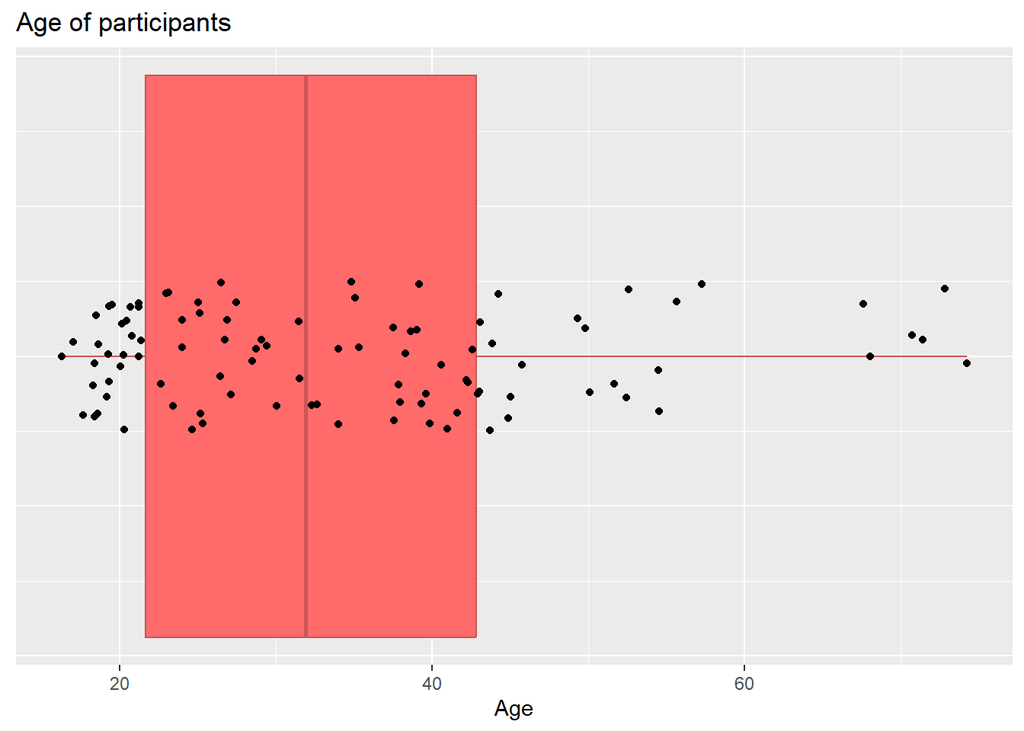

```r
ggplot(data = Marriage, mapping = aes(x=age)) +
  geom_boxplot(fill = "indianred1",
               color = "indianred3") +
  geom_jitter(aes(y=0), height=0.1) +
  labs(title="Age of participants", x="Age", y=NULL) +
  theme(axis.text.y = element_blank(),
        axis.ticks.y = element_blank())
```

## Violin Plot

The boxplots were invented in the 1970s and were popular to be used due to their simplicity to draw by hand. However, they do not display much information about the data as they summarize the data into a few values only. More recently, we see boxplots being replaced with violin plots, or a combination of boxplot and violin plot.

The violin plot is quite similar to the kernel density plot where kernels are used to estimate the distribution of the data. It is often used to compare distribution between different groups.

In ggplot2, the function `geom_violin()` can be used to draw a violin plot. If we only have one group, we need to use `x=""` in the `aes()` function in `ggplot`.

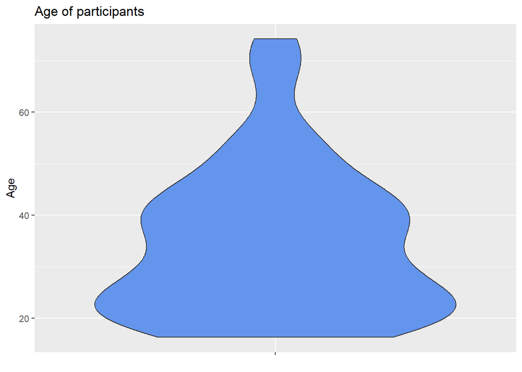

```r
ggplot(data = Marriage, mapping = aes(x="", y=age)) +
  geom_violin(fill="cornflowerblue") +
  labs(title="Age of participants", y="Age", x=NULL)
```

Just like kernel density plot, we can specify the bandwidth or the smoothing parameter by changing `bw` argument in `geom_violin()`.

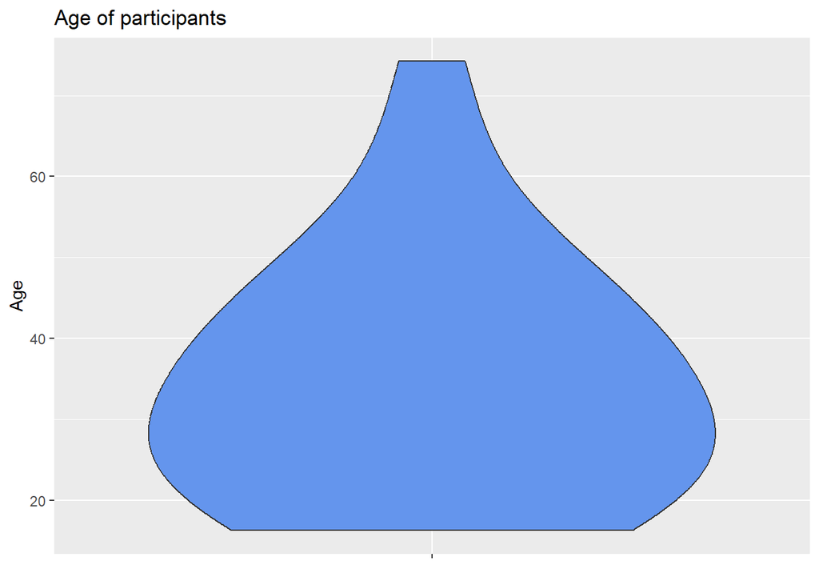

```r
ggplot(data = Marriage, mapping = aes(x="", y=age)) +
  geom_violin(bw=10,
              fill="cornflowerblue") +
  labs(title="Age of participants", y="Age", x=NULL)
```

To change the orientation of the violin plot, we can modify the `orientation` argument in `geom_violin()` and change the x and y in the `aes()` mapping.

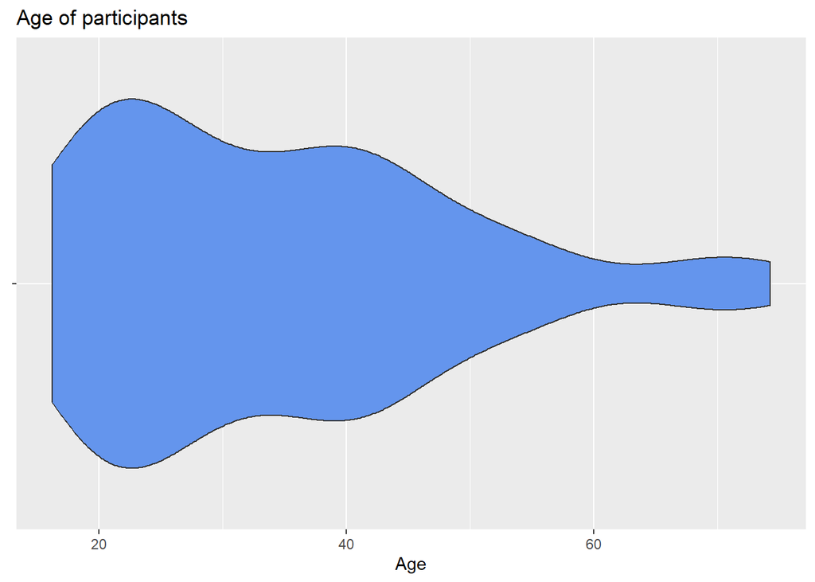

```r
ggplot(data = Marriage, mapping = aes(y="", x=age)) +
  geom_violin(fill="cornflowerblue", orientation="y") +
  labs(title="Age of participants", x="Age", y=NULL)
```

If we want to, we can use boxplot, violin plot, and jitter at the same time.

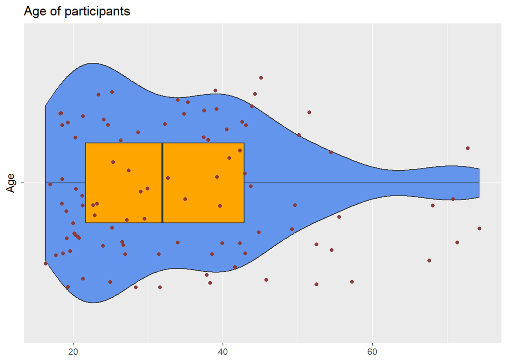

```r
ggplot(data = Marriage, mapping = aes(y="", x=age)) +
  geom_violin(fill="cornflowerblue", orientation="y") +
  geom_boxplot(width=0.3,
               fill="orange") +
  geom_jitter(width=0.1,
              color="indianred4") +
  labs(title="Age of participants", y="Age", x=NULL)
```

## Conclusion

In this topic, we have discussed about the visuals and plots we can use to describe the distribution of quantitative data, including the histogram, kernel density plot, frequency polygon, boxplot, and violin plot. In the next topic, we will discuss about visuals used to make group comparison, where we have more than one group and we want to see the difference between them. Some of the plots we have talked in this topic and the previous topic will be used again.